# Question

A wrap-around L-shaped patio will measure $y$ feet along one wall and $z$ feet along another wall. The patio will stick out $x$ feet from the walls, and the total area will be 1184 square feet. *Note: you can assume all angles are right angles.*

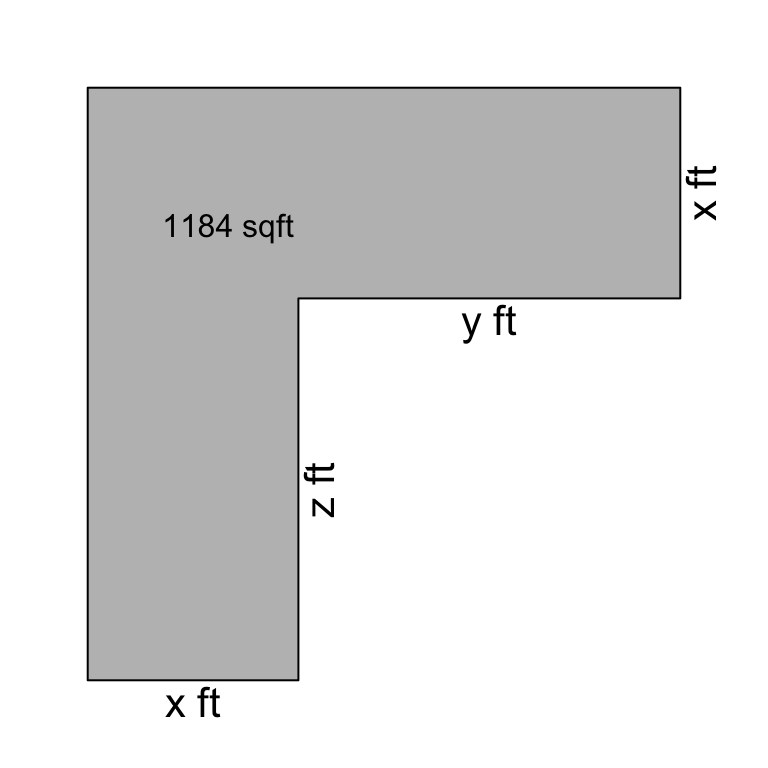

You know that the sum of $y$ and $z$ is 58.

$$y+z=58$$

What value of $x$ satisfies the conditions stated above?

# Solution

It is easiest to just assume $y=z$ in order to make a square. So, divide 58 by two.

$$\frac{58}{2}~=~29$$

We can write an equation by saying the sum of $x^2$ and $29x$ and $29x$ equals 1184. These expressions represent the areas of a small square and two rectangles.

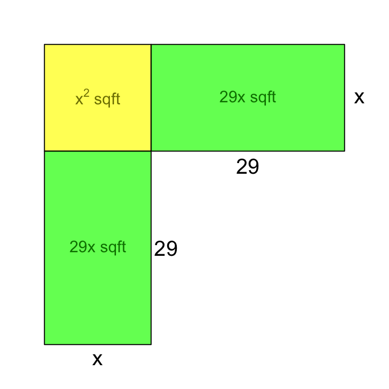

$$x^2+29x+29x~=~1184$$

Combine like terms.

$$x^2+58x~=~1184$$

There is a fun way to solve this. We will “complete the square”. In this situation, we imagine adding some extra area to the picture to make a large square. In this case, we need to add a square with edge lengths of 29, adding 841 square feet to the area.

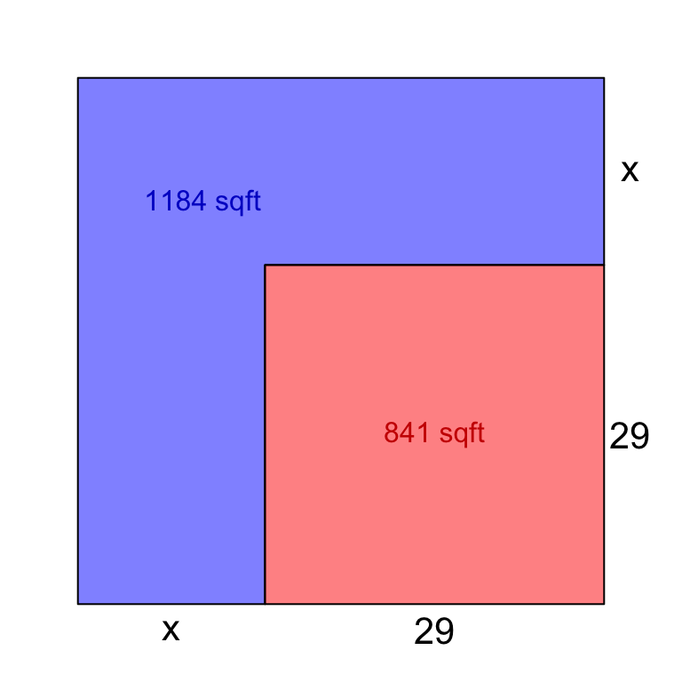

$$x^2+58x+841~=~1184+841$$

$$x^2+58x+841~=~2025$$

But, notice, if you look at the last picture, we have another way to represent the total area. The newly formed large square has side lengths of $x+29$. So we can represent the total area of the large square as $(x+29)^2$.

$$(x+29)^2~=~2025$$

Undo the squaring on both sides. Use a calculator to find that $\sqrt{2025}=45$.

$$x+29~=~\pm 45$$

And, lastly, subtract 29 from both sides of the equation.

$$x~=~-29 \pm 45$$

We are only interesting in the positive value.

$$x~=~-29 + 45$$

$$x~=~16$$

# Meta-information

extype: num exsolution: 16 exname: complete_the_square_C